# Data Science I, Workshop I: Predicting interest rates at the Lending Club

# 9 Using Time Information

Let’s try to further improve the model’s predictive performance. So far we have not used any time series information. Effectively, all things being equal, our prediction for the interest rate of a loan given in 2009 would be the same as that of a loan given in 2011. We do not think it a good assumption and we are now taking into consideration the time series information to fix this in our previous models.

First, we investigate graphically whether there are any time trends in the interest rates. (Note that the variable “issue_d” only has information on the month the loan was awarded but not the exact date.) We want to use this to improve the model by tring controlling for time in a linear fashion (i.e., a linear time trend) and controlling for time as quarter-year dummies (this is a method to capture non-linear effects of time – we assume that the impact of time doesn’t change within a quarter but it can chance from quarter to quarter). Finally, we checked if time affect loans of different grades differently.

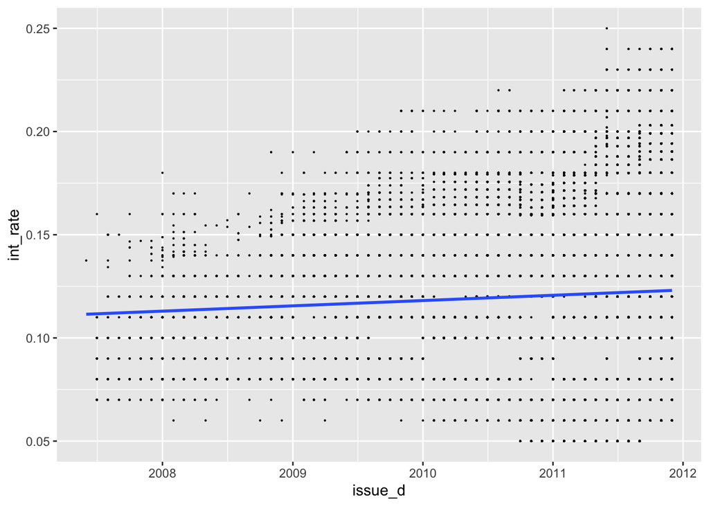

```r
#linear time trend (add code below)
ggplot(lc_clean, aes(x=issue_d, y=int_rate))+
  geom_point(size=0.1)+
  geom_smooth(method = "lm", se=FALSE)
```

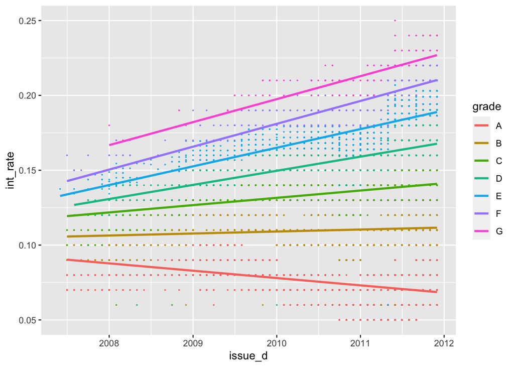

```r
#linear time trend by grade (add code below)
ggplot(lc_clean, aes(x=issue_d, y=int_rate, color=grade))+
  geom_point(size=0.1)+
  geom_smooth(method = "lm", se=FALSE)
```

```r
#Train models using OLS regression and k-fold cross-validation
#The first model has some explanatory variables and a linear time trend

time1<-train(
  int_rate ~ loan_amnt*grade + term +dti + quartiles_annual_inc + issue_d , #fill your variables here "+ issue_d"
  lc_clean,
  method = "lm",
  trControl = control)
summary(time1)
```

```
##
## Call:
## lm(formula = .outcome ~ ., data = dat)
##
## Residuals:
##       Min        1Q    Median        3Q       Max
## -0.118983 -0.006602 -0.000730  0.006935  0.036319
##
## Coefficients:
##                         Estimate Std. Error t value Pr(>|t|)
## (Intercept)           -2.492e-02  2.512e-03  -9.921  < 2e-16 ***
## loan_amnt              1.008e-07  2.014e-08   5.001 5.71e-07 ***
## gradeB                 3.607e-02  2.681e-04 134.564  < 2e-16 ***
## gradeC                 6.244e-02  2.934e-04 212.772  < 2e-16 ***
## gradeD                 8.127e-02  3.419e-04 237.674  < 2e-16 ***
## gradeE                 9.727e-02  4.542e-04 214.134  < 2e-16 ***
## gradeF                 1.152e-01  7.591e-04 151.828  < 2e-16 ***
## gradeG                 1.336e-01  1.521e-03  87.854  < 2e-16 ***
## term60                 2.238e-03  1.453e-04  15.400  < 2e-16 ***
## dti                    8.506e-06  8.133e-06   1.046 0.295631
## quartiles_annual_inc2 -2.541e-04  1.518e-04  -1.674 0.094150 .
## quartiles_annual_inc3 -4.275e-04  1.560e-04  -2.740 0.006139 **
## quartiles_annual_inc4 -5.694e-04  1.660e-04  -3.430 0.000603 ***
## issue_d                6.542e-06  1.690e-07  38.700  < 2e-16 ***
## `loan_amnt:gradeB`    -8.054e-11  2.401e-08  -0.003 0.997323
## `loan_amnt:gradeC`    -1.200e-07  2.574e-08  -4.661 3.15e-06 ***
## `loan_amnt:gradeD`     1.151e-07  2.747e-08   4.189 2.80e-05 ***
## `loan_amnt:gradeE`     2.459e-07  2.959e-08   8.311  < 2e-16 ***
## `loan_amnt:gradeF`     3.005e-07  4.057e-08   7.407 1.31e-13 ***
## `loan_amnt:gradeG`     1.599e-07  7.120e-08   2.246 0.024721 *
## ---
## Signif. codes:  0 '***' 0.001 '**' 0.01 '*' 0.05 '.' 0.1 ' ' 1
##
## Residual standard error: 0.01031 on 37849 degrees of freedom
## Multiple R-squared:  0.9234, Adjusted R-squared:  0.9234
## F-statistic: 2.403e+04 on 19 and 37849 DF,  p-value: < 2.2e-16
```

```r
#The second model has a different linear time trend for each grade class
time2<-train(
    int_rate ~ loan_amnt*grade + term +dti + quartiles_annual_inc + issue_d * grade, #fill your variables here
    lc_clean,
   method = "lm",
    trControl = control
   )
summary(time2)
```

```
##
## Call:
## lm(formula = .outcome ~ ., data = dat)
##
## Residuals:
##       Min        1Q    Median        3Q       Max
## -0.120720 -0.006613 -0.000134  0.006753  0.030865
##
## Coefficients:
##                         Estimate Std. Error t value Pr(>|t|)
## (Intercept)            2.862e-01  4.357e-03  65.681  < 2e-16 ***
## loan_amnt              3.156e-07  1.786e-08  17.673  < 2e-16 ***
## gradeB                -2.298e-01  5.808e-03 -39.573  < 2e-16 ***
## gradeC                -3.541e-01  6.178e-03 -57.315  < 2e-16 ***
## gradeD                -5.147e-01  7.197e-03 -71.510  < 2e-16 ***
## gradeE                -6.134e-01  9.904e-03 -61.935  < 2e-16 ***
## gradeF                -7.098e-01  1.612e-02 -44.042  < 2e-16 ***
## gradeG                -7.102e-01  3.314e-02 -21.432  < 2e-16 ***
## term60                -6.331e-04  1.304e-04  -4.856 1.20e-06 ***
## dti                    5.407e-05  7.148e-06   7.564 4.00e-14 ***
## quartiles_annual_inc2 -2.976e-04  1.332e-04  -2.234  0.02547 *
## quartiles_annual_inc3 -3.926e-04  1.369e-04  -2.869  0.00412 **
## quartiles_annual_inc4 -5.857e-04  1.456e-04  -4.022 5.79e-05 ***
## issue_d               -1.443e-05  2.935e-07 -49.179  < 2e-16 ***
## `loan_amnt:gradeB`    -1.560e-07  2.122e-08  -7.352 1.99e-13 ***
## `loan_amnt:gradeC`    -3.231e-07  2.283e-08 -14.154  < 2e-16 ***
## `loan_amnt:gradeD`    -1.771e-07  2.435e-08  -7.276 3.50e-13 ***
## `loan_amnt:gradeE`    -1.725e-07  2.658e-08  -6.489 8.76e-11 ***
## `loan_amnt:gradeF`    -1.865e-07  3.677e-08  -5.072 3.95e-07 ***
## `loan_amnt:gradeG`    -2.944e-07  6.439e-08  -4.572 4.85e-06 ***
## `gradeB:issue_d`       1.791e-05  3.903e-07  45.877  < 2e-16 ***
## `gradeC:issue_d`       2.807e-05  4.165e-07  67.402  < 2e-16 ***
## `gradeD:issue_d`       4.019e-05  4.849e-07  82.884  < 2e-16 ***
## `gradeE:issue_d`       4.799e-05  6.679e-07  71.852  < 2e-16 ***
## `gradeF:issue_d`       5.568e-05  1.085e-06  51.309  < 2e-16 ***
## `gradeG:issue_d`       5.695e-05  2.230e-06  25.541  < 2e-16 ***
## ---
## Signif. codes:  0 '***' 0.001 '**' 0.01 '*' 0.05 '.' 0.1 ' ' 1
##
## Residual standard error: 0.009048 on 37843 degrees of freedom
## Multiple R-squared:  0.9411, Adjusted R-squared:  0.9411
## F-statistic: 2.418e+04 on 25 and 37843 DF,  p-value: < 2.2e-16
```

```r
#Change the time trend to a quarter dummy variables.
#zoo::as.yearqrt() creates quarter dummies
lc_clean_quarter<-lc_clean %>%
  mutate(yq = as.factor(as.yearqtr(lc_clean$issue_d, format = "%Y-%m-%d")))



time3<-train(
    int_rate ~ loan_amnt*grade + term +dti + quartiles_annual_inc + yq,#fill your variables here
    lc_clean_quarter,
     method = "lm",
    trControl = control
   )
summary(time3)
```

```
##
## Call:
## lm(formula = .outcome ~ ., data = dat)
##
## Residuals:
##       Min        1Q    Median        3Q       Max
## -0.116112 -0.005421 -0.000205  0.005814  0.037669
##
## Coefficients:
##                         Estimate Std. Error t value Pr(>|t|)
## (Intercept)            3.826e-02  9.075e-03   4.215 2.50e-05 ***
## loan_amnt              1.089e-07  1.777e-08   6.127 9.02e-10 ***
## gradeB                 3.657e-02  2.359e-04 155.008  < 2e-16 ***
## gradeC                 6.248e-02  2.584e-04 241.762  < 2e-16 ***
## gradeD                 8.095e-02  3.011e-04 268.891  < 2e-16 ***
## gradeE                 9.699e-02  4.000e-04 242.508  < 2e-16 ***
## gradeF                 1.154e-01  6.679e-04 172.748  < 2e-16 ***
## gradeG                 1.338e-01  1.338e-03  99.989  < 2e-16 ***
## term60                 4.576e-03  1.311e-04  34.916  < 2e-16 ***
## dti                    5.287e-06  7.157e-06   0.739 0.460068
## quartiles_annual_inc2 -2.258e-04  1.336e-04  -1.690 0.090965 .
## quartiles_annual_inc3 -3.008e-04  1.373e-04  -2.191 0.028469 *
## quartiles_annual_inc4 -2.185e-04  1.462e-04  -1.495 0.134997
## `yq2007 Q3`            1.931e-02  9.136e-03   2.113 0.034581 *
## `yq2007 Q4`            1.486e-02  9.103e-03   1.632 0.102672
## `yq2008 Q1`            2.129e-02  9.082e-03   2.345 0.019051 *
## `yq2008 Q2`            2.292e-02  9.090e-03   2.522 0.011677 *
## `yq2008 Q3`            2.407e-02  9.100e-03   2.645 0.008161 **
## `yq2008 Q4`            3.201e-02  9.083e-03   3.525 0.000425 ***
## `yq2009 Q1`            3.619e-02  9.079e-03   3.986 6.74e-05 ***
## `yq2009 Q2`            3.803e-02  9.078e-03   4.189 2.80e-05 ***
## `yq2009 Q3`            3.957e-02  9.077e-03   4.359 1.31e-05 ***
## `yq2009 Q4`            3.981e-02  9.076e-03   4.386 1.16e-05 ***
## `yq2010 Q1`            3.480e-02  9.076e-03   3.834 0.000126 ***
## `yq2010 Q2`            3.355e-02  9.075e-03   3.697 0.000219 ***
## `yq2010 Q3`            3.464e-02  9.075e-03   3.817 0.000135 ***
## `yq2010 Q4`            2.592e-02  9.075e-03   2.856 0.004290 **
## `yq2011 Q1`            2.805e-02  9.075e-03   3.091 0.001996 **
## `yq2011 Q2`            3.321e-02  9.075e-03   3.660 0.000253 ***
## `yq2011 Q3`            3.561e-02  9.074e-03   3.925 8.70e-05 ***
## `yq2011 Q4`            4.184e-02  9.074e-03   4.611 4.02e-06 ***
## `loan_amnt:gradeB`    -1.076e-07  2.117e-08  -5.083 3.73e-07 ***
## `loan_amnt:gradeC`    -2.140e-07  2.271e-08  -9.421  < 2e-16 ***
## `loan_amnt:gradeD`     5.910e-08  2.422e-08   2.440 0.014700 *
## `loan_amnt:gradeE`     1.812e-07  2.609e-08   6.943 3.89e-12 ***
## `loan_amnt:gradeF`     2.255e-07  3.573e-08   6.311 2.81e-10 ***
## `loan_amnt:gradeG`     1.121e-07  6.265e-08   1.789 0.073581 .
## ---
## Signif. codes:  0 '***' 0.001 '**' 0.01 '*' 0.05 '.' 0.1 ' ' 1
##
## Residual standard error: 0.00907 on 37832 degrees of freedom
## Multiple R-squared:  0.9408, Adjusted R-squared:  0.9408
## F-statistic: 1.671e+04 on 36 and 37832 DF,  p-value: < 2.2e-16
```

```r
#We specify one quarter dummy variable for each grade. This is going to be a large model as there are 19 quarters x 7 grades = 133 quarter-grade dummies.
time4<-train(
    int_rate ~ loan_amnt*grade + term +dti + quartiles_annual_inc + yq * grade, #fill your variables here
    lc_clean_quarter,
     method = "lm",
    trControl = control
   )
summary(time4)
```

```
##
## Call:
## lm(formula = .outcome ~ ., data = dat)
##
## Residuals:
##       Min        1Q    Median        3Q       Max
## -0.120445 -0.004941  0.000306  0.004671  0.034212
##
## Coefficients: (11 not defined because of singularities)
##                         Estimate Std. Error t value Pr(>|t|)
## (Intercept)            1.858e-02  7.578e-03   2.451 0.014248 *
## loan_amnt              3.008e-07  1.510e-08  19.922  < 2e-16 ***
## gradeB                 4.305e-02  3.193e-04 134.841  < 2e-16 ***
## gradeC                 6.974e-02  3.622e-04 192.538  < 2e-16 ***
## gradeD                 9.702e-02  4.189e-04 231.621  < 2e-16 ***
## gradeE                 1.177e-01  5.380e-04 218.715  < 2e-16 ***
## gradeF                 1.390e-01  8.637e-04 160.926  < 2e-16 ***
## gradeG                 1.603e-01  1.800e-03  89.015  < 2e-16 ***
## term60                 1.727e-03  1.131e-04  15.276  < 2e-16 ***
## dti                    4.804e-05  5.991e-06   8.017 1.11e-15 ***
## quartiles_annual_inc2 -2.415e-04  1.116e-04  -2.165 0.030375 *
## quartiles_annual_inc3 -2.668e-04  1.146e-04  -2.327 0.019978 *
## quartiles_annual_inc4 -1.833e-04  1.221e-04  -1.501 0.133291
## `yq2007 Q3`            5.495e-02  7.722e-03   7.116 1.13e-12 ***
## `yq2007 Q4`            5.596e-02  7.711e-03   7.257 4.03e-13 ***
## `yq2008 Q1`            5.958e-02  7.616e-03   7.823 5.27e-15 ***
## `yq2008 Q2`            6.104e-02  7.651e-03   7.978 1.53e-15 ***
## `yq2008 Q3`            6.042e-02  7.687e-03   7.860 3.96e-15 ***
## `yq2008 Q4`            6.682e-02  7.616e-03   8.773  < 2e-16 ***
## `yq2009 Q1`            6.852e-02  7.598e-03   9.017  < 2e-16 ***
## `yq2009 Q2`            6.798e-02  7.593e-03   8.953  < 2e-16 ***
## `yq2009 Q3`            6.614e-02  7.589e-03   8.715  < 2e-16 ***
## `yq2009 Q4`            6.414e-02  7.587e-03   8.454  < 2e-16 ***
## `yq2010 Q1`            5.714e-02  7.586e-03   7.532 5.10e-14 ***
## `yq2010 Q2`            5.506e-02  7.583e-03   7.260 3.93e-13 ***
## `yq2010 Q3`            5.502e-02  7.583e-03   7.256 4.08e-13 ***
## `yq2010 Q4`            4.396e-02  7.581e-03   5.799 6.73e-09 ***
## `yq2011 Q1`            4.584e-02  7.580e-03   6.047 1.49e-09 ***
## `yq2011 Q2`            4.672e-02  7.580e-03   6.164 7.16e-10 ***
## `yq2011 Q3`            4.691e-02  7.579e-03   6.189 6.10e-10 ***
```

[output cut: 106 more lines]

```
## `gradeE:yq2011 Q3`     1.596e-03  5.763e-04   2.770 0.005611 **
## `gradeF:yq2011 Q3`     9.203e-04  8.587e-04   1.072 0.283847
## `gradeG:yq2011 Q3`    -1.687e-03  1.643e-03  -1.027 0.304369
## `gradeB:yq2011 Q4`            NA         NA      NA       NA
## `gradeC:yq2011 Q4`            NA         NA      NA       NA
## `gradeD:yq2011 Q4`            NA         NA      NA       NA
## `gradeE:yq2011 Q4`            NA         NA      NA       NA
## `gradeF:yq2011 Q4`            NA         NA      NA       NA
## `gradeG:yq2011 Q4`            NA         NA      NA       NA
## ---
## Signif. codes:  0 '***' 0.001 '**' 0.01 '*' 0.05 '.' 0.1 ' ' 1
##
## Residual standard error: 0.007563 on 37735 degrees of freedom
## Multiple R-squared:  0.959,  Adjusted R-squared:  0.9588
## F-statistic:  6628 on 133 and 37735 DF,  p-value: < 2.2e-16
```

```r
data.frame(
  time1$results$RMSE,
  time2$results$RMSE,
  time3$results$RMSE,
  time4$results$RMSE)
```

| time1.results.RMSE | time2.results.RMSE | time3.results.RMSE | time4.results.RMSE |
| --- | --- | --- | --- |
| 0.0103 | 0.00905 | 0.00908 | 0.00758 |

## 9.1 Q8 Prediction improvement by adding time information

- From the results of linear regressions, we find almost all the time related variables significant. Therefore, the interest rates do change over time.
- The predictions can be improved by adding quarter-year dummies. The RMSE has been improved from 0.0103 to 0.0076.

# 10 Using Bond Yields

One concern with using time trends for forecasting is that in order to make predictions for future loans we will need to project trends to the future. This is an extrapolation that may not be reasonable, especially if macroeconomic conditions in the future change. Furthermore, if we are using quarter-year dummies, it is not even possible to estimate the coefficient of these dummy variables for future quarters.

Instead, perhaps it’s better to find the reasons as to why different periods are different from one another. The csv file “MonthBondYields.csv” contains information on the yield of US Treasuries on the first day of each month. Can you use it to see if you can improve your predictions without using time dummies?

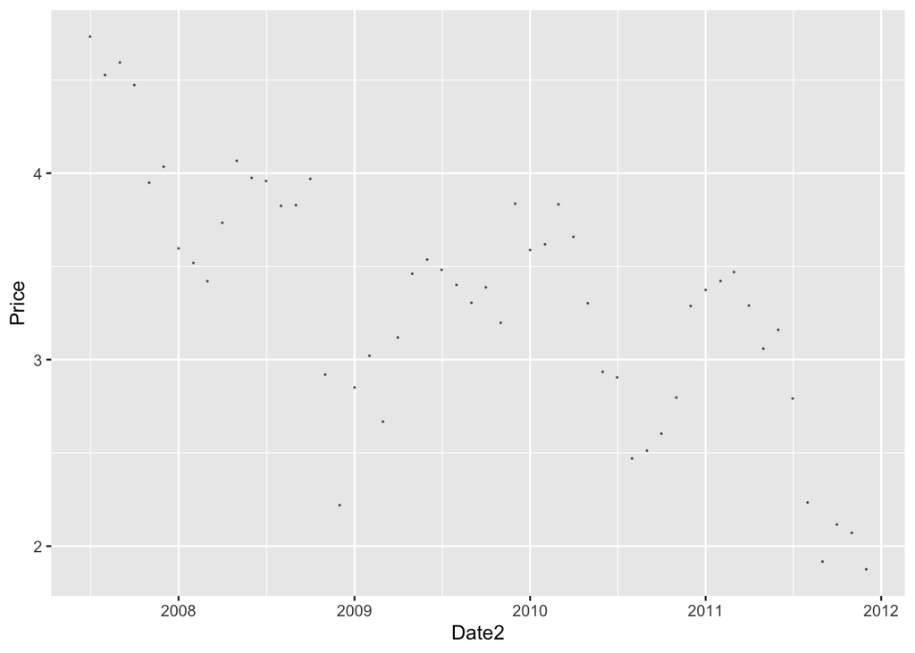

```r
#load the data to memory as a dataframe
bond_prices<-readr::read_csv("MonthBondYields.csv")

#make the date of the bond file comparable to the lending club dataset
#for some regional date/number (locale) settings this may not work. If it does try running the following line of code in the Console
#Sys.setlocale("LC_TIME","English")
bond_prices <- bond_prices %>%
  mutate(Date2=as.Date(paste("01",Date,sep="-"),"%d-%b-%y")) %>%
  select(-starts_with("X"))

#let's see what happened to bond yields over time. Lower bond yields mean the cost of borrowing has gone down.

bond_prices %>%
  ggplot(aes(x=Date2, y=Price))+
  geom_point(size=0.1, alpha=0.5)
```

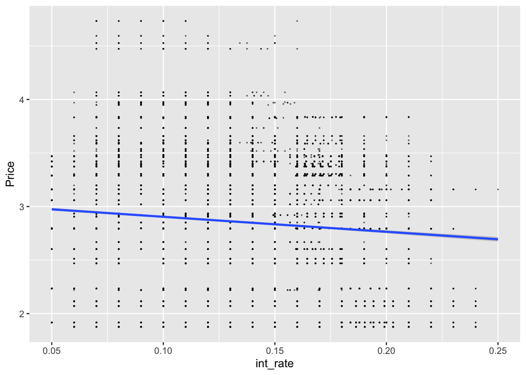

```r
#join the data using a left join
lc_with_bonds <- lc_clean %>%
  mutate(yq = as.factor(as.yearqtr(lc_clean$issue_d, format = "%Y-%m-%d"))) %>%
  left_join(bond_prices, by = c("issue_d" = "Date2")) %>%
  arrange(issue_d) %>%
  filter(!is.na(Price)) #drop any observations where there re no bond prices available

# investigate graphically if there is a relationship
lc_with_bonds%>%
  ggplot(aes(x=int_rate, y=Price))+
  geom_point(size=0.1, alpha=0.5)+geom_smooth(method="lm")
```

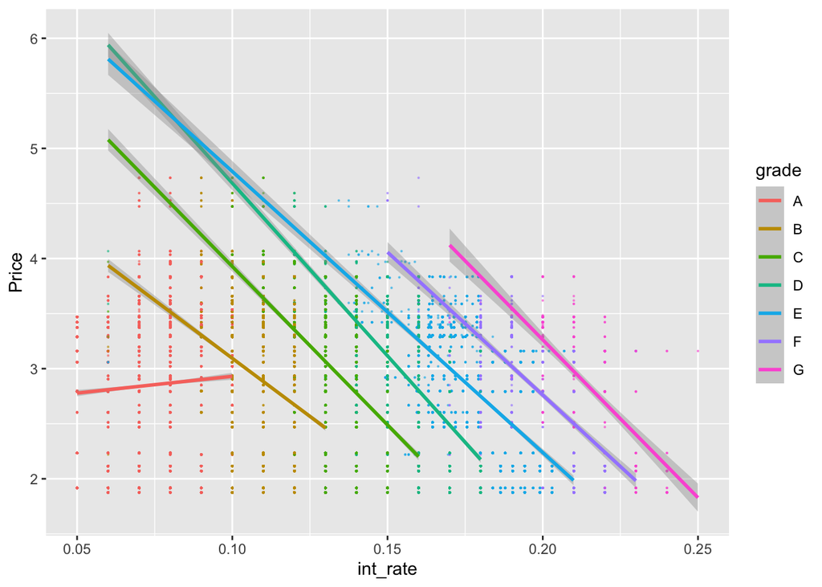

```r
lc_with_bonds%>%
  ggplot(aes(x=int_rate, y=Price, color=grade))+
  geom_point(size=0.1, alpha=0.5)+
  geom_smooth(method="lm")
```

```r
#let's train a model using the bond information
control <- trainControl (
    method="cv",
    number=10,
    verboseIter=TRUE)

plsFit<-train(
    int_rate ~  loan_amnt*grade + term +dti + Price * grade,
    lc_with_bonds,
    method = "lm",
    trControl = control
   )
summary(plsFit)
```

```
##
## Call:
## lm(formula = .outcome ~ ., data = dat)
##
## Residuals:
##       Min        1Q    Median        3Q       Max
## -0.117450 -0.005810 -0.000302  0.006494  0.040734
##
## Coefficients:
##                      Estimate Std. Error t value Pr(>|t|)
## (Intercept)         6.791e-02  5.361e-04 126.679  < 2e-16 ***
## loan_amnt           1.795e-07  1.863e-08   9.638  < 2e-16 ***
## gradeB              5.350e-02  6.990e-04  76.538  < 2e-16 ***
## gradeC              8.631e-02  7.843e-04 110.051  < 2e-16 ***
## gradeD              1.192e-01  8.941e-04 133.269  < 2e-16 ***
## gradeE              1.433e-01  1.167e-03 122.786  < 2e-16 ***
## gradeF              1.667e-01  1.791e-03  93.096  < 2e-16 ***
## gradeG              1.903e-01  3.456e-03  55.057  < 2e-16 ***
## term60              1.506e-03  1.323e-04  11.378  < 2e-16 ***
## dti                 2.802e-05  7.453e-06   3.760 0.000171 ***
## Price               1.301e-03  1.626e-04   8.005 1.22e-15 ***
## `loan_amnt:gradeB` -9.477e-08  2.249e-08  -4.214 2.51e-05 ***
## `loan_amnt:gradeC` -2.195e-07  2.416e-08  -9.088  < 2e-16 ***
## `loan_amnt:gradeD` -1.987e-09  2.572e-08  -0.077 0.938417
## `loan_amnt:gradeE`  6.441e-08  2.787e-08   2.311 0.020827 *
## `loan_amnt:gradeF`  6.990e-08  3.840e-08   1.820 0.068693 .
## `loan_amnt:gradeG` -1.206e-07  6.770e-08  -1.781 0.074911 .
## `gradeB:Price`     -5.774e-03  2.181e-04 -26.470  < 2e-16 ***
## `gradeC:Price`     -8.000e-03  2.429e-04 -32.934  < 2e-16 ***
## `gradeD:Price`     -1.274e-02  2.794e-04 -45.585  < 2e-16 ***
## `gradeE:Price`     -1.527e-02  3.611e-04 -42.287  < 2e-16 ***
## `gradeF:Price`     -1.667e-02  5.359e-04 -31.103  < 2e-16 ***
## `gradeG:Price`     -1.780e-02  9.982e-04 -17.829  < 2e-16 ***
## ---
## Signif. codes:  0 '***' 0.001 '**' 0.01 '*' 0.05 '.' 0.1 ' ' 1
##
## Residual standard error: 0.009584 on 37845 degrees of freedom
## Multiple R-squared:  0.9339, Adjusted R-squared:  0.9339
## F-statistic: 2.43e+04 on 22 and 37845 DF,  p-value: < 2.2e-16
```

## 10.1 Q9 Explanatory power of bond yields

- We are using loan amount times grade,term, dti and Price times grade to predict the interest rates
- Yes, by adding bond yields to the model, the adjusted R square increased by 0.01, and the bond yields are significant on every grade.
- With increase in bond yield (price) by 1%, the interest rates on the loan increase by 0.13% on Grade A loans. As the grade decreases (A to G) the effect of bond yields (price) on the interest rate starts to become negative. This means that as treasury yields (price) increases, the effect on interest rates start to decrease.

## 10.2 Q10 Model Comparison

```r
TestModel1<-train(
    int_rate ~  loan_amnt*grade + term +dti + Price * grade,
    lc_with_bonds,
    method = "lm",
    trControl = control
   )
summary(TestModel1)
```

```
##
## Call:
## lm(formula = .outcome ~ ., data = dat)
##
## Residuals:
##       Min        1Q    Median        3Q       Max
## -0.117450 -0.005810 -0.000302  0.006494  0.040734
##
## Coefficients:
##                      Estimate Std. Error t value Pr(>|t|)
## (Intercept)         6.791e-02  5.361e-04 126.679  < 2e-16 ***
## loan_amnt           1.795e-07  1.863e-08   9.638  < 2e-16 ***
## gradeB              5.350e-02  6.990e-04  76.538  < 2e-16 ***
## gradeC              8.631e-02  7.843e-04 110.051  < 2e-16 ***
## gradeD              1.192e-01  8.941e-04 133.269  < 2e-16 ***
## gradeE              1.433e-01  1.167e-03 122.786  < 2e-16 ***
## gradeF              1.667e-01  1.791e-03  93.096  < 2e-16 ***
## gradeG              1.903e-01  3.456e-03  55.057  < 2e-16 ***
## term60              1.506e-03  1.323e-04  11.378  < 2e-16 ***
## dti                 2.802e-05  7.453e-06   3.760 0.000171 ***
## Price               1.301e-03  1.626e-04   8.005 1.22e-15 ***
## `loan_amnt:gradeB` -9.477e-08  2.249e-08  -4.214 2.51e-05 ***
## `loan_amnt:gradeC` -2.195e-07  2.416e-08  -9.088  < 2e-16 ***
## `loan_amnt:gradeD` -1.987e-09  2.572e-08  -0.077 0.938417
## `loan_amnt:gradeE`  6.441e-08  2.787e-08   2.311 0.020827 *
## `loan_amnt:gradeF`  6.990e-08  3.840e-08   1.820 0.068693 .
## `loan_amnt:gradeG` -1.206e-07  6.770e-08  -1.781 0.074911 .
## `gradeB:Price`     -5.774e-03  2.181e-04 -26.470  < 2e-16 ***
## `gradeC:Price`     -8.000e-03  2.429e-04 -32.934  < 2e-16 ***
## `gradeD:Price`     -1.274e-02  2.794e-04 -45.585  < 2e-16 ***
## `gradeE:Price`     -1.527e-02  3.611e-04 -42.287  < 2e-16 ***
## `gradeF:Price`     -1.667e-02  5.359e-04 -31.103  < 2e-16 ***
## `gradeG:Price`     -1.780e-02  9.982e-04 -17.829  < 2e-16 ***
## ---
## Signif. codes:  0 '***' 0.001 '**' 0.01 '*' 0.05 '.' 0.1 ' ' 1
##
## Residual standard error: 0.009584 on 37845 degrees of freedom
## Multiple R-squared:  0.9339, Adjusted R-squared:  0.9339
## F-statistic: 2.43e+04 on 22 and 37845 DF,  p-value: < 2.2e-16
```

```r
# TestModel2<-train(
#     int_rate ~  loan_amnt*grade + term +dti + Price * grade + quartiles_annual_inc + home_ownership + addr_state ,
#     lc_with_bonds,
#     method = "lm",
#     trControl = control
#    )
# summary(TestModel2)
#
# TestModel3<-train(
#     int_rate ~  loan_amnt*grade + term +dti + Price * grade + quartiles_annual_inc + term*loan_amnt,
#     lc_with_bonds,
#     method = "lm",
#     trControl = control
#    )
# summary(TestModel3)
```

## 10.3 Q11 Further improvements

Adding quarterly data on US [CPI](https://fred.stlouisfed.org/series/CPALTT01USQ657N):

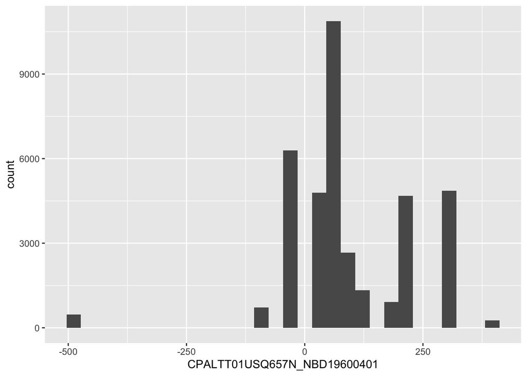

```r
cpi <- readr::read_csv("ConsumerPriceIndex.csv") %>%
  mutate(yq = as.factor(as.yearqtr(DATE, format = "%Y-%m-%d")))

lc_bonds_cpi <- lc_with_bonds %>%
  left_join(cpi, by = c("yq")) %>%
  arrange(issue_d) %>%
  filter(!is.na(CPALTT01USQ657N_NBD19600401)) #drop any observations where there re no bond prices available

# investigate graphically if there is a relationship
lc_bonds_cpi%>%
  ggplot(aes(x=CPALTT01USQ657N_NBD19600401))+
  geom_histogram()
```

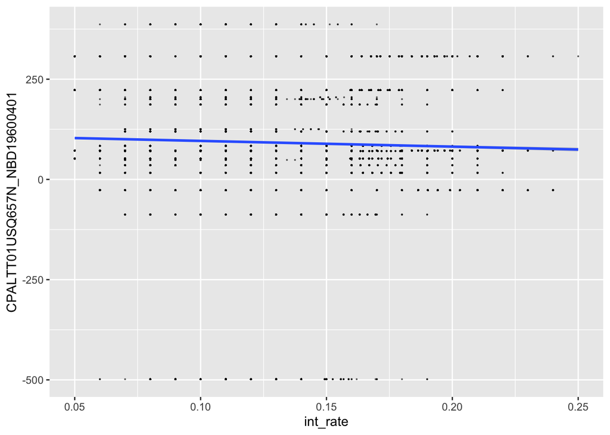

```r
# investigate graphically if there is a relationship
lc_bonds_cpi%>%
  ggplot(aes(x=int_rate, y=CPALTT01USQ657N_NBD19600401))+
  geom_point(size=0.1, alpha=0.5)+
  geom_smooth(method="lm")
```

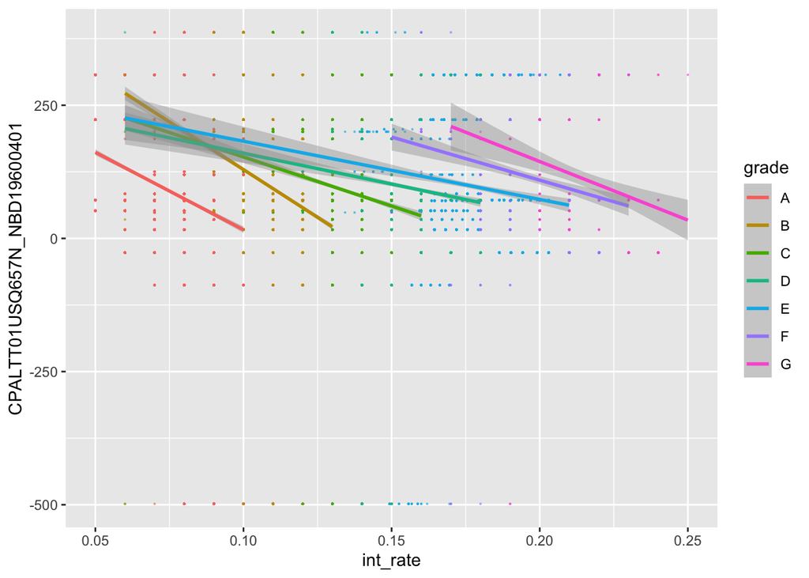

```r
lc_bonds_cpi%>%
  ggplot(aes(x=int_rate, y=CPALTT01USQ657N_NBD19600401, color=grade))+
  geom_point(size=0.1, alpha=0.5)+
  geom_smooth(method="lm")
```

```r
plsFit<-train(
    int_rate ~  loan_amnt*grade + term +dti +  Price*grade+ CPALTT01USQ657N_NBD19600401 * grade, #fill your variables here
    lc_bonds_cpi,
    method = "lm",
    trControl = control
   )
summary(plsFit)
```

```
##
## Call:
## lm(formula = .outcome ~ ., data = dat)
##
## Residuals:
##       Min        1Q    Median        3Q       Max
## -0.118658 -0.006044  0.000158  0.006133  0.036126
##
## Coefficients:
##                                        Estimate Std. Error t value Pr(>|t|)
## (Intercept)                           6.126e-02  5.479e-04 111.807  < 2e-16 ***
## loan_amnt                             1.788e-07  1.802e-08   9.922  < 2e-16 ***
## gradeB                                5.823e-02  7.151e-04  81.438  < 2e-16 ***
## gradeC                                9.425e-02  8.014e-04 117.599  < 2e-16 ***
## gradeD                                1.307e-01  9.211e-04 141.854  < 2e-16 ***
## gradeE                                1.605e-01  1.253e-03 128.052  < 2e-16 ***
## gradeF                                1.881e-01  1.998e-03  94.156  < 2e-16 ***
## gradeG                                2.073e-01  3.733e-03  55.517  < 2e-16 ***
## term60                                8.458e-04  1.316e-04   6.428 1.31e-10 ***
## dti                                   3.628e-05  7.218e-06   5.026 5.03e-07 ***
## Price                                 4.686e-03  1.810e-04  25.897  < 2e-16 ***
## CPALTT01USQ657N_NBD19600401          -3.294e-05  8.684e-07 -37.935  < 2e-16 ***
## `loan_amnt:gradeB`                   -8.482e-08  2.176e-08  -3.897 9.74e-05 ***
## `loan_amnt:gradeC`                   -2.087e-07  2.338e-08  -8.926  < 2e-16 ***
## `loan_amnt:gradeD`                   -9.708e-09  2.490e-08  -0.390   0.6966
## `loan_amnt:gradeE`                    1.818e-08  2.708e-08   0.671   0.5021
## `loan_amnt:gradeF`                    6.319e-09  3.744e-08   0.169   0.8660
## `loan_amnt:gradeG`                   -1.540e-07  6.578e-08  -2.342   0.0192 *
## `gradeB:Price`                       -8.189e-03  2.423e-04 -33.794  < 2e-16 ***
## `gradeC:Price`                       -1.200e-02  2.668e-04 -44.980  < 2e-16 ***
## `gradeD:Price`                       -1.837e-02  3.103e-04 -59.204  < 2e-16 ***
## `gradeE:Price`                       -2.315e-02  4.237e-04 -54.637  < 2e-16 ***
## `gradeF:Price`                       -2.646e-02  6.832e-04 -38.735  < 2e-16 ***
## `gradeG:Price`                       -2.564e-02  1.223e-03 -20.958  < 2e-16 ***
## `gradeB:CPALTT01USQ657N_NBD19600401`  2.277e-05  1.158e-06  19.662  < 2e-16 ***
## `gradeC:CPALTT01USQ657N_NBD19600401`  3.827e-05  1.232e-06  31.071  < 2e-16 ***
## `gradeD:CPALTT01USQ657N_NBD19600401`  5.315e-05  1.437e-06  36.997  < 2e-16 ***
## `gradeE:CPALTT01USQ657N_NBD19600401`  6.583e-05  1.870e-06  35.193  < 2e-16 ***
## `gradeF:CPALTT01USQ657N_NBD19600401`  7.705e-05  3.175e-06  24.266  < 2e-16 ***
## `gradeG:CPALTT01USQ657N_NBD19600401`  6.397e-05  5.445e-06  11.750  < 2e-16 ***
## ---
## Signif. codes:  0 '***' 0.001 '**' 0.01 '*' 0.05 '.' 0.1 ' ' 1
##
## Residual standard error: 0.009273 on 37838 degrees of freedom
## Multiple R-squared:  0.9381, Adjusted R-squared:  0.9381
## F-statistic: 1.978e+04 on 29 and 37838 DF,  p-value: < 2.2e-16
```

## 10.4 Analysis on additional data

- We would think that the additional data on inflation will make a difference because by adding both the bond yield and the inflation rate as variables to the model, it will give us a more accurate view on the real interest rate at the time.
- However, when running the model, we can see that the adjusted r-squared only increases by more than 0.4% to 93.81%. The model also has a lower RMSE, making the predictions more accurate.

# 11 Team members

- Alex Kubbinga
- Clara Moreno Sanchez
- Jean Huang
- Raghav Mehta
- Raina Doshi
- Yuan Gao